# Annotating rethomics plots

Quentin Geissmann

2 March 2016

## Aims

In this tutorial, we will learn how to:

- use `ggplot` to transform your plot
- Put LD annotations on your graphs

## Just ggplot

[ggplot](http://ggplot2.org/) is an extremely powerful visualisation tool for `R`. It is very well documented and widely used, which is why `rethomics` generates `ggplot` based graphs. At this stage, I would recommend to read a bnit about `ggplot`, of follow a [video tutorial](https://www.youtube.com/watch?v=RHu5vgBZ1yQ) by it’s author.

Before we start on our own plot, I wanted to remind you a bit how ggplot works with some *completely unrelated data*:

```r
data(iris)
print(head(iris))
```

```
##   Sepal.Length Sepal.Width Petal.Length Petal.Width Species
## 1          5.1         3.5          1.4         0.2  setosa
## 2          4.9         3.0          1.4         0.2  setosa
## 3          4.7         3.2          1.3         0.2  setosa
## 4          4.6         3.1          1.5         0.2  setosa
## 5          5.0         3.6          1.4         0.2  setosa
## 6          5.4         3.9          1.7         0.4  setosa
```

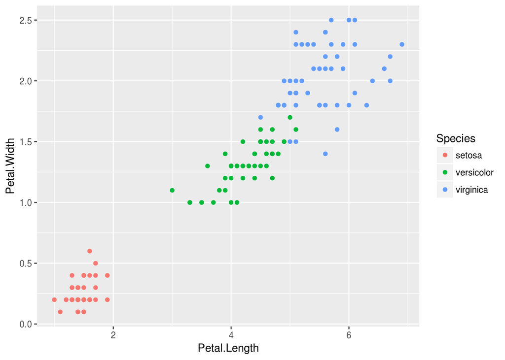

```r
# we create a ggplot object that works on iris

pl <- ggplot(iris, aes(Petal.Length, Petal.Width, colour=Species)) + geom_point()
pl
```

Now the key point I want to show is that you can modify a plot (`pl`) after is is made:

```r
data(iris)
print(head(iris))
```

```
##   Sepal.Length Sepal.Width Petal.Length Petal.Width Species
## 1          5.1         3.5          1.4         0.2  setosa
## 2          4.9         3.0          1.4         0.2  setosa
## 3          4.7         3.2          1.3         0.2  setosa
## 4          4.6         3.1          1.5         0.2  setosa
## 5          5.0         3.6          1.4         0.2  setosa
## 6          5.4         3.9          1.7         0.4  setosa
```

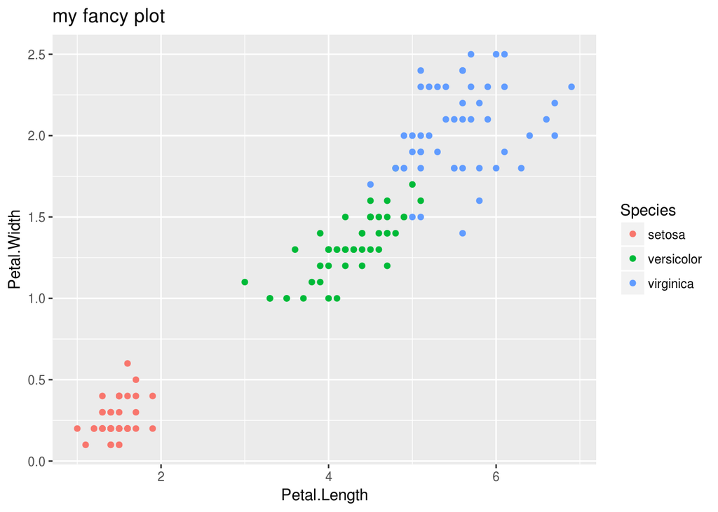

```r
# we create a ggplot object that works on iris

pl2 <- pl + labs(title="my fancy plot")
#this one has a title
pl2
```

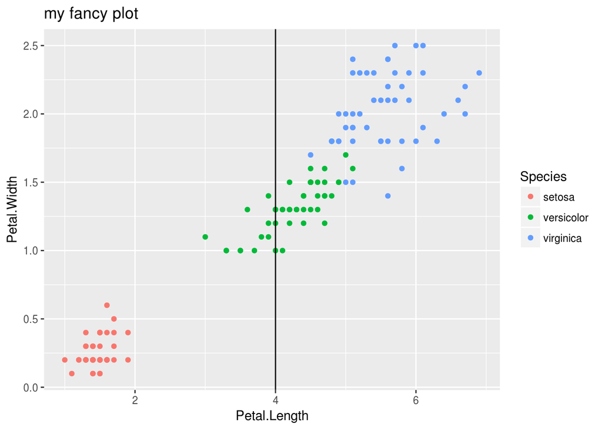

```r
# you can also annotate/draw/...
pl3 <- pl2 + geom_vline(xintercept=4)
pl3
```

Let us use the same plot as in the `ethogramPlot` tutorial and call it `pl`.

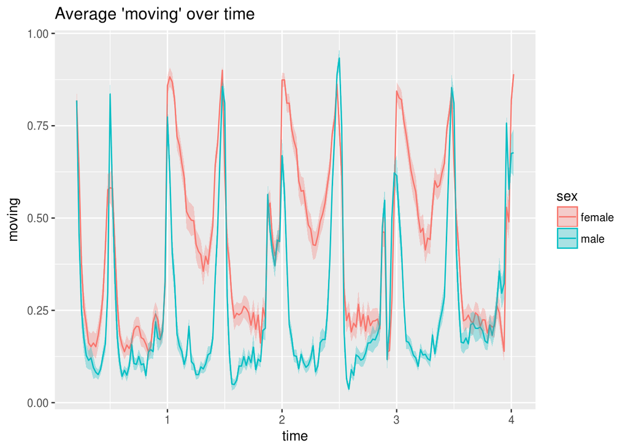

```r
data(sleep_sexual_dimorphism)
dt <- sleep_sexual_dimorphism
pl <- ethogramPlot(moving, dt, sex, error_bar="sem")
pl
```

Now our plot is just a ggplot object, so you can also annotate it:

Let us start by putting more meaningful axis labels/title

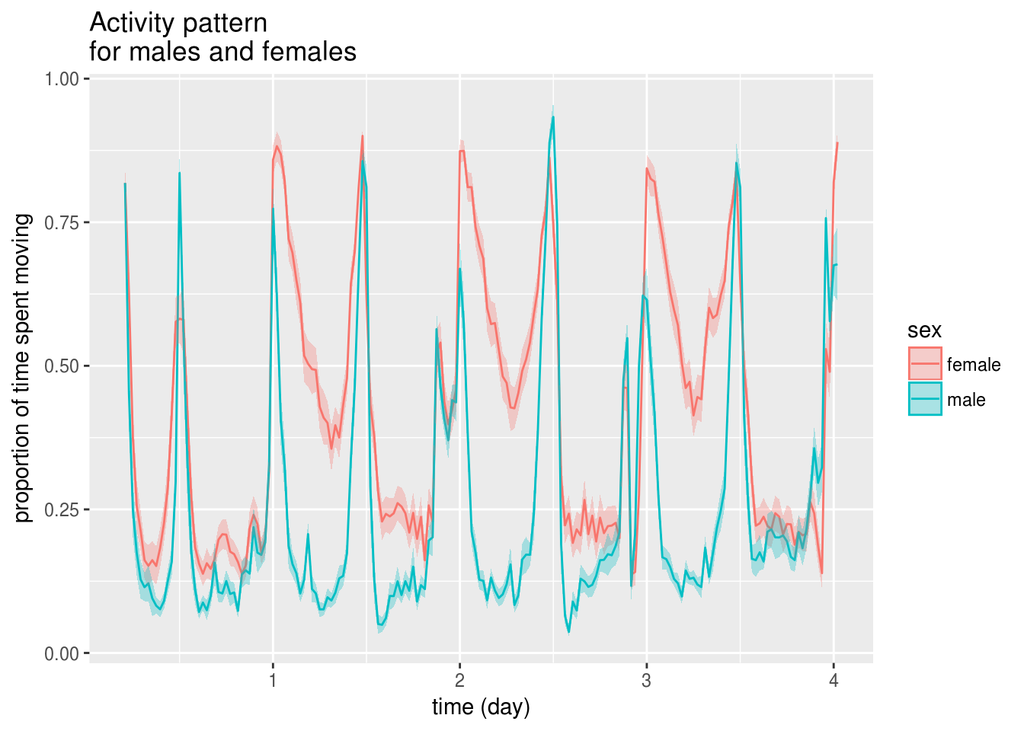

```r
pl <- pl + labs(  title="Activity pattern\nfor males and females",
            x="time (day)", y="proportion of time spent moving" )
pl
```

## LD annotations

Another common thing you may want to do is add LD (light/dark phase) annotations:

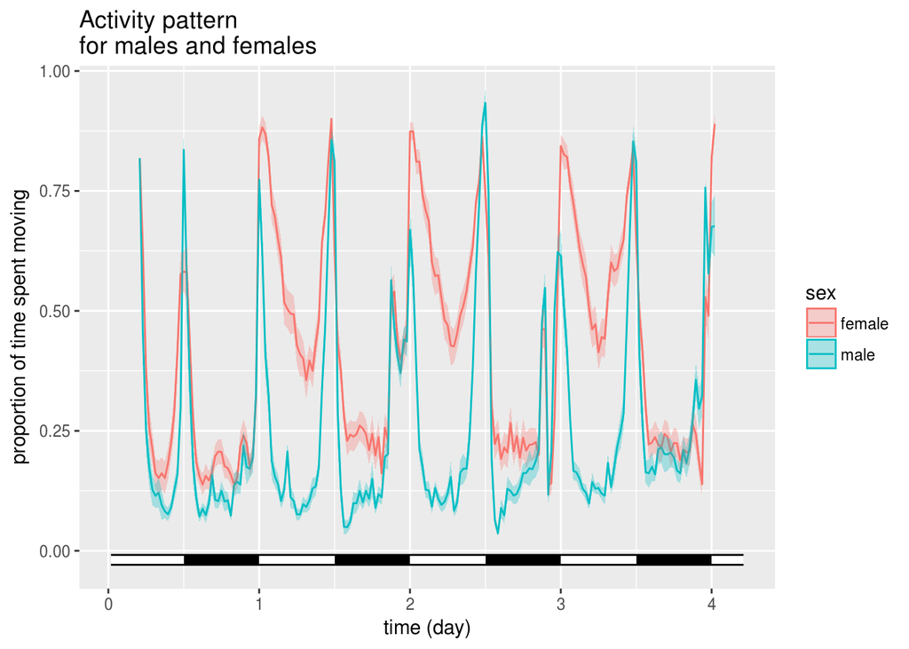

```r
pl <- makeLDAnnotation(pl)
pl
```

A last thing that could be of interest, is the use of text, arrows, segments on graphs. For instance, imagine that you wanted to show, to the readers of the figure, that you applied a treatment at a given time, say at day 2:

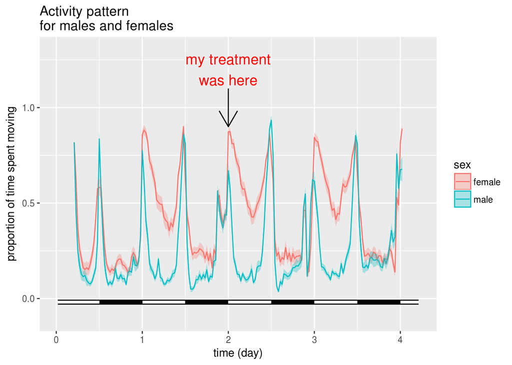

```r
pl +
    # here, we add a vertical arrow
    annotate("segment", x=2, y=1.1, xend=2, yend=0.9, arrow = arrow()) +
    # then some text
    annotate("text", label = "my treatment\nwas here", x = 2, y = 1.2, size = 5, colour = "red") +
    # we can also change the scale
    scale_y_continuous(limits=c(-0.1,1.3))
```

This is just a quick overview, but Many more annotations and ways to modify plots can be found in `ggplot`.